# Alpha1-Antitrypsin

## Figure 5: Per-residue ΔΔG fold-preference contribution

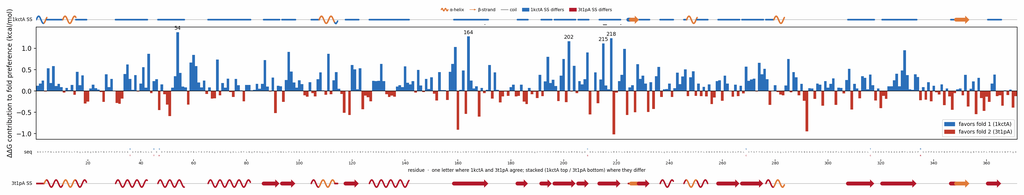

**More figures**

## Figure 6: Deep-MSA contact map panel / Best clusters contact map panel

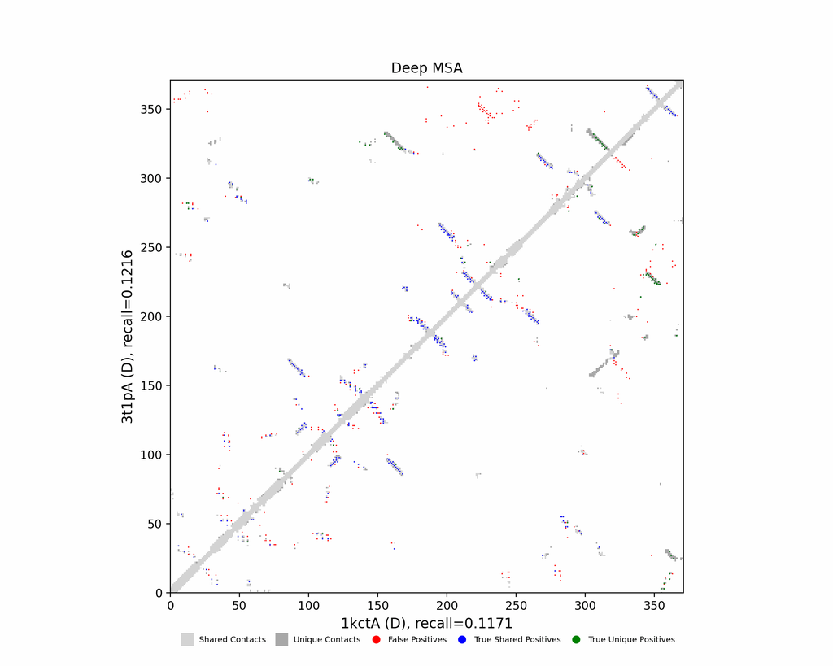

Deep-MSA contact map panel

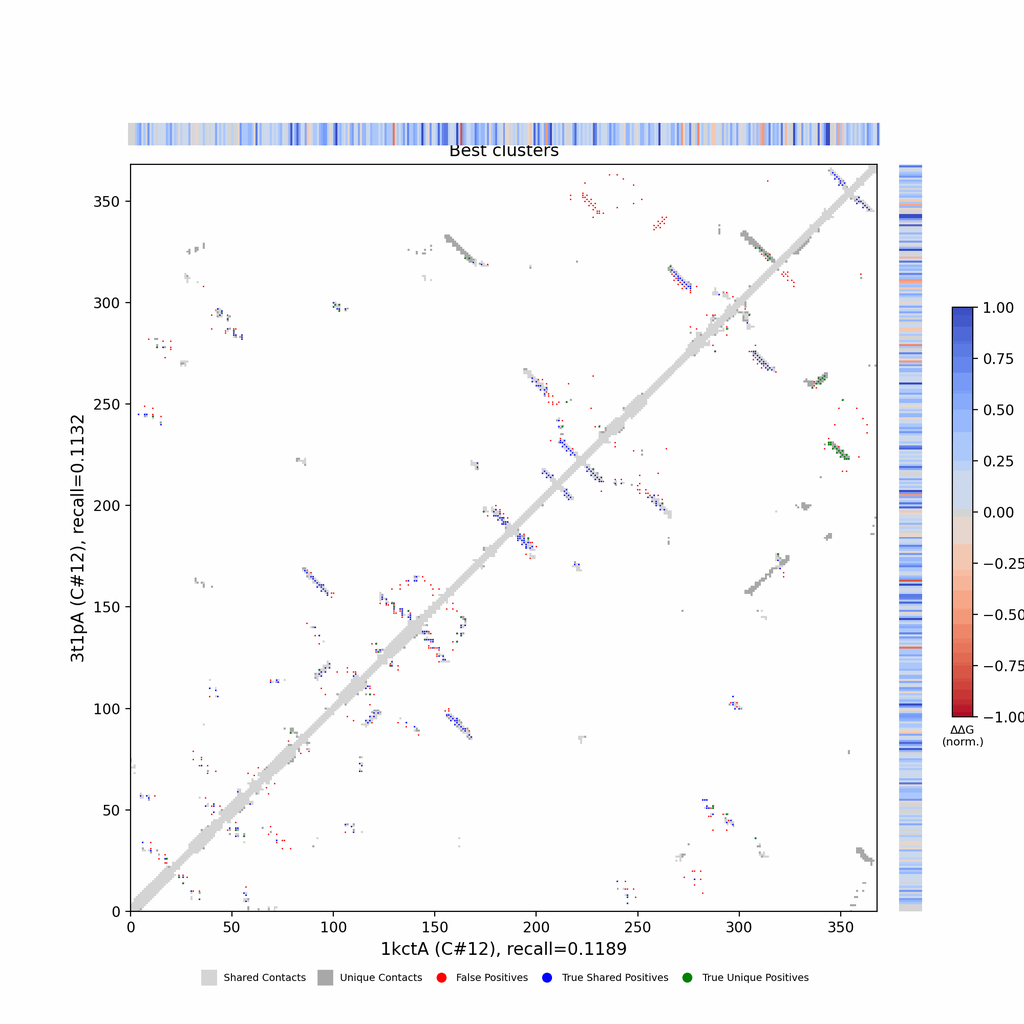

Best clusters contact map panel

## Figure 7: All clusters contact-map mosaic (small multiples).

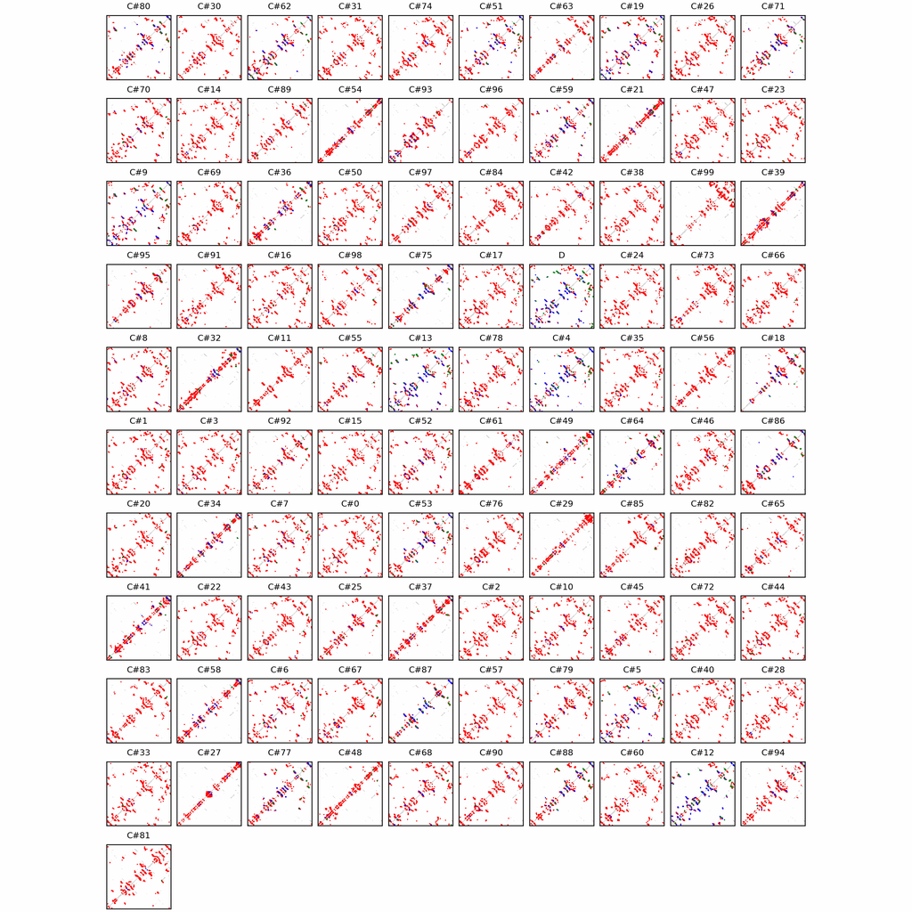

## Figure 8: Phylo null: tree with shuffled cluster fold labels.

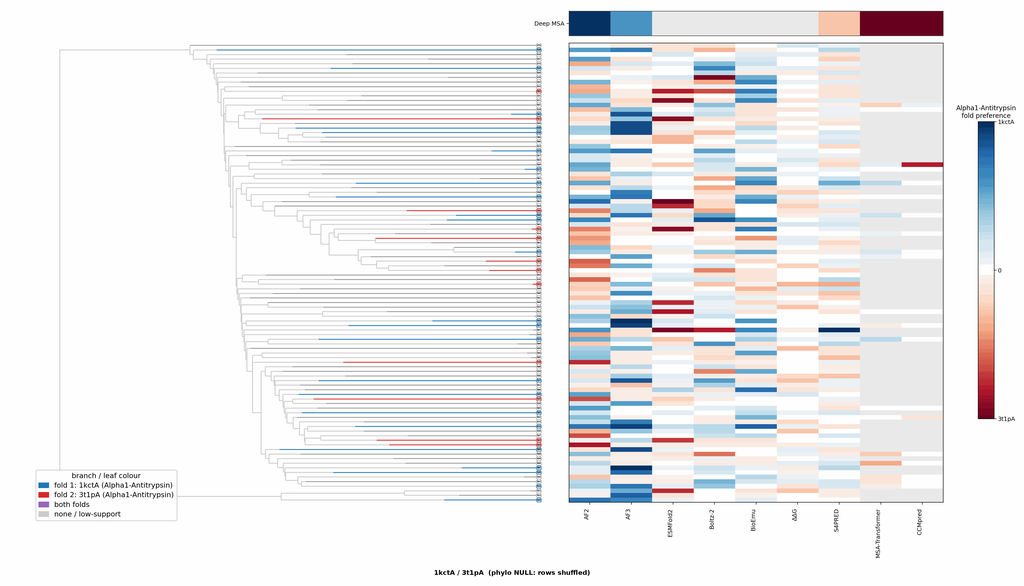

## Cluster metrics table

Per-cluster metrics underlying the figures above.

| cluster | n | neff | AF2_TM1 | AF2_TM2 | AF3_TM1 | AF3_TM2 | RE-MSAT-COM | RE-MSAT1 | RE-MSAT2 | ESM_SEQIDS | ESM_TM1 | ESM_TM2 | ΔΔG_Bias | ΔΔG_Bias_std | ΔΔG_frac_F1 | Boltz2_pref | S4PRED_pref | CCMpred_pref | BioEmu_pref |
| --- | --- | --- | --- | --- | --- | --- | --- | --- | --- | --- | --- | --- | --- | --- | --- | --- | --- | --- | --- |
| Deep | - | - | 0.94 | 0.83 | 0.94 | 0.84 | 0.4 | 0.38 | 0.41 | - | - | - | - | - | - | - | -0.03 | -0.01 | - |
| 000 | 953.0 | 649.0 | 0.49 | 0.41 | 0.76 | 0.85 | 0.01 | 0.01 | 0.01 | 003; 003; 002; 002; 008; 008; 001; 001; 009; 004 | 0.88 ± 0.01 | 0.78 ± 0.02 | 42.6 | 15.16 | 1.0 | 0.03 | -0.07 | -0.01 | 0.01 |
| 001 | 789.0 | 553.0 | 0.44 | 0.37 | 0.77 | 0.87 | 0.02 | 0.03 | 0.03 | 001; 007; 007; 005; 001; 005; 008; 009; 004; 004 | 0.88 ± 0.00 | 0.79 ± 0.02 | 41.56 | 11.92 | 1.0 | 0.05 | -0.05 | 0.0 | 0.0 |
| 002 | 620.0 | 429.0 | 0.56 | 0.49 | 0.77 | 0.86 | 0.0 | 0.0 | 0.0 | 004; 004; 001; 002; 002; 001; 005; 005; 010; 003 | 0.85 ± 0.03 | 0.80 ± 0.01 | 41.79 | 14.64 | 1.0 | 0.0 | -0.05 | -0.0 | 0.06 |
| 003 | 549.0 | 394.0 | 0.71 | 0.66 | 0.75 | 0.83 | 0.01 | 0.01 | 0.01 | 004; 004; 005; 005; 001; 001; 002; 002; 003; 003 | 0.85 ± 0.01 | 0.80 ± 0.01 | 45.65 | 14.36 | 1.0 | 0.05 | -0.03 | -0.0 | 0.03 |
| 004 | 539.0 | 259.0 | 0.27 | 0.27 | 0.27 | 0.22 | 0.38 | 0.34 | 0.32 | 001; 001; 002; 002; 005; 009; 005; 009; 010; 010 | 0.89 ± 0.01 | 0.80 ± 0.03 | 37.53 | 14.3 | 1.0 | 0.05 | -0.04 | 0.0 | 0.02 |
| 005 | 526.0 | 373.0 | 0.42 | 0.33 | 0.77 | 0.85 | 0.18 | 0.2 | 0.19 | 001; 001; 002; 002; 005; 005; 007; 007; 008; 008 | 0.88 ± 0.03 | 0.77 ± 0.04 | 42.04 | 13.39 | 1.0 | 0.02 | -0.06 | 0.0 | 0.03 |
| 006 | 504.0 | 254.0 | 0.26 | 0.24 | 0.23 | 0.21 | 0.04 | 0.04 | 0.04 | 005; 005; 010; 010; 002; 002; 001; 001; 009; 003 | 0.87 ± 0.02 | 0.80 ± 0.02 | 41.86 | 15.2 | 1.0 | -0.01 | -0.05 | 0.0 | 0.01 |
| 007 | 437.0 | 256.0 | 0.24 | 0.22 | 0.43 | 0.34 | 0.04 | 0.04 | 0.04 | 001; 001; 003; 003; 002; 002; 004; 004; 007; 007 | 0.83 ± 0.07 | 0.76 ± 0.05 | 41.2 | 18.75 | 1.0 | 0.01 | -0.04 | 0.0 | 0.01 |
| 008 | 424.0 | 280.0 | 0.48 | 0.41 | 0.76 | 0.84 | 0.03 | 0.04 | 0.03 | 001; 001; 002; 002; 007; 004; 007; 004; 003; 003 | 0.89 ± 0.03 | 0.79 ± 0.03 | 42.26 | 16.36 | 1.0 | -0.04 | -0.05 | 0.0 | 0.02 |
| 009 | 397.0 | 268.0 | 0.35 | 0.29 | 0.74 | 0.83 | 0.19 | 0.21 | 0.21 | 010; 010; 009; 009; 005; 003; 001; 005; 003; 001 | 0.85 ± 0.00 | 0.78 ± 0.02 | 44.99 | 15.55 | 1.0 | 0.0 | -0.02 | 0.0 | 0.01 |
| 010 | 356.0 | 209.0 | 0.46 | 0.4 | 0.87 | 0.82 | 0.02 | 0.03 | 0.02 | 005; 005; 004; 004; 001; 001; 009; 009; 002; 002 | 0.87 ± 0.02 | 0.79 ± 0.01 | 42.87 | 15.12 | 1.0 | 0.0 | -0.04 | 0.0 | 0.06 |
| 011 | 314.0 | 133.0 | 0.29 | 0.23 | 0.29 | 0.24 | 0.0 | 0.0 | 0.0 | 002; 004; 004; 002; 001; 006; 003; 001; 006; 003 | 0.86 ± 0.00 | 0.80 ± 0.02 | 32.44 | 12.87 | 1.0 | 0.04 | -0.03 | 0.0 | 0.02 |
| 012 | 312.0 | 215.0 | 0.48 | 0.43 | 0.76 | 0.85 | 0.4 | 0.37 | 0.36 | 001; 003; 001; 003; 002; 002; 004; 004; 009; 009 | 0.88 ± 0.01 | 0.78 ± 0.02 | 37.74 | 16.1 | 1.0 | 0.04 | -0.05 | 0.0 | 0.06 |
| 013 | 289.0 | 214.0 | 0.28 | 0.27 | 0.27 | 0.26 | 0.37 | 0.37 | 0.4 | 003; 003; 004; 004; 001; 001; 002; 002; 005; 005 | 0.88 ± 0.01 | 0.80 ± 0.02 | 39.46 | 13.53 | 1.0 | 0.01 | -0.06 | 0.0 | 0.0 |
| 014 | 287.0 | 219.0 | 0.24 | 0.26 | 0.76 | 0.84 | 0.01 | 0.0 | 0.01 | 001; 001; 002; 002; 005; 005; 004; 006; 006; 004 | 0.88 ± 0.02 | 0.77 ± 0.03 | 41.32 | 13.15 | 1.0 | 0.01 | -0.05 | 0.0 | 0.01 |
| 015 | 287.0 | 196.0 | 0.5 | 0.43 | 0.82 | 0.84 | 0.0 | 0.0 | 0.0 | 001; 002; 002; 001; 005; 004; 003; 003; 004; 005 | 0.87 ± 0.01 | 0.78 ± 0.02 | 43.8 | 17.8 | 1.0 | 0.01 | -0.04 | 0.0 | 0.04 |
| 016 | 284.0 | 198.0 | 0.6 | 0.62 | 0.76 | 0.84 | 0.01 | 0.01 | 0.01 | 001; 001; 003; 002; 003; 002; 008; 008; 009; 010 | 0.87 ± 0.01 | 0.80 ± 0.01 | 43.3 | 15.71 | 1.0 | 0.01 | -0.04 | 0.0 | 0.04 |
| 017 | 269.0 | 195.0 | 0.36 | 0.28 | 0.75 | 0.84 | 0.01 | 0.01 | 0.01 | 002; 002; 004; 004; 001; 005; 003; 001; 005; 003 | 0.87 ± 0.01 | 0.78 ± 0.03 | 41.37 | 13.25 | 1.0 | 0.03 | -0.04 | 0.0 | 0.06 |
| 018 | 267.0 | 84.0 | 0.28 | 0.29 | 0.29 | 0.29 | 0.1 | 0.09 | 0.08 | 005; 005; 002; 003; 003; 002; 001; 009; 006; 001 | 0.86 ± 0.01 | 0.79 ± 0.00 | 33.0 | 14.66 | 1.0 | 0.03 | -0.04 | 0.0 | 0.0 |
| 019 | 265.0 | 196.0 | 0.83 | 0.75 | 0.75 | 0.83 | 0.18 | 0.18 | 0.18 | 005; 005; 001; 001; 006; 002; 002; 006; 003; 003 | 0.88 ± 0.01 | 0.79 ± 0.01 | 41.7 | 13.6 | 1.0 | 0.01 | 0.01 | 0.0 | 0.07 |
| 020 | 260.0 | 155.0 | 0.72 | 0.68 | 0.76 | 0.84 | 0.02 | 0.02 | 0.02 | - | - | - | 46.0 | 15.07 | 1.0 | 0.07 | -0.06 | - | 0.02 |
| 021 | 247.0 | 25.0 | 0.26 | 0.24 | 0.26 | 0.25 | 0.0 | 0.0 | 0.0 | - | - | - | 26.58 | 11.47 | 1.0 | 0.01 | -0.05 | - | 0.0 |
| 022 | 245.0 | 142.0 | 0.25 | 0.24 | 0.51 | 0.44 | 0.0 | 0.01 | 0.01 | - | - | - | 38.76 | 12.76 | 1.0 | 0.01 | -0.05 | - | 0.01 |
| 023 | 245.0 | 187.0 | 0.37 | 0.31 | 0.74 | 0.82 | 0.01 | 0.02 | 0.02 | - | - | - | 41.23 | 11.89 | 1.0 | 0.0 | -0.07 | - | 0.01 |
| 024 | 242.0 | 175.0 | 0.51 | 0.49 | 0.73 | 0.81 | 0.0 | 0.0 | 0.0 | - | - | - | 45.62 | 18.89 | 1.0 | 0.01 | -0.06 | - | 0.02 |
| 025 | 237.0 | 86.0 | 0.33 | 0.23 | 0.27 | 0.23 | 0.01 | 0.02 | 0.01 | - | - | - | 39.7 | 16.16 | 1.0 | 0.01 | -0.05 | - | 0.02 |
| 026 | 227.0 | 158.0 | 0.24 | 0.21 | 0.3 | 0.28 | 0.0 | 0.0 | 0.0 | - | - | - | 40.11 | 15.48 | 1.0 | 0.01 | -0.06 | - | 0.01 |
| 027 | 216.0 | 33.0 | 0.25 | 0.21 | 0.4 | 0.33 | 0.01 | 0.0 | 0.0 | - | - | - | 25.7 | 13.4 | 1.0 | 0.06 | -0.04 | - | 0.0 |
| 028 | 202.0 | 139.0 | 0.47 | 0.54 | 0.75 | 0.84 | 0.0 | 0.0 | 0.01 | - | - | - | 38.77 | 11.37 | 1.0 | 0.01 | -0.04 | - | 0.01 |

[output cut: 71 more lines]